# Aula 3 - Semana 1

Ivanildo Batista

9 de fevereiro de 2021

## Curso Financial Risk Management with R - Semana 1

### Calculating Longer Returns (Aula 3)

Nessa aula foi ensinado sobre o calculo de retornos para periodos maiores que 1 dia. Esse periodo para calcular o retorno pode ser 2 dias, 3 dias, uma semana, um mes, um ano, etc.

Como dito anteriormente, para calcular o retorno comecamos com o logaritmo do retorno para um dia, calcula-se o retorno de *t-1* para *t*

$$logret_t$$
Calculando o logaritmo do retorno para 2 dias, teremos que fazer de *t-2* para *t*:

$$logret_t + logret_{t-1}$$
Para encontrar o retorno discreto *exponencializando* o resultado anterior e subtraindo o valor 1:

$$exp(logret_t + logret_{t-1}) - 1$$
Quando queremos encontrar o logaritmo do retorno para periodos de tempo maiores, seguimos o seguinte passo:

Calculamos o logaritmo do retorno
$$logret_t$$
Calcula-se o logaritmo do retorno para *n* dias:
$$logret_t + logret_{t-1} + logret_{t-2} + ... + logret_{t-n+1}$$
E, por fim, *exponencializamos* esse resultado e subtraimos 1:
$$exp(logret_t + logret_{t-1} + logret_{t-2} + ... + logret_{t-n+1}) - 1$$

Antes de realizarmos os calculos, irei fazer o que foi feito nas aulas passadas:

```r
library(quantmod)
wilsh = getSymbols("WILL5000IND", src = "FRED", auto.assign = FALSE)
```

[output not shown]

```r
wilsh = na.omit(wilsh)
wilsh = wilsh['1979-12-31/2017-12-31']
names(wilsh) = "TR"
```

```r
logret_d = apply.daily(wilsh,sum)
```

Visualizando as tres primeiras linhas

```r
round(head(logret_d,3),6)
```

```
##              TR
## 1979-12-31 1.90
## 1980-01-02 1.86
## 1980-01-04 1.88
```

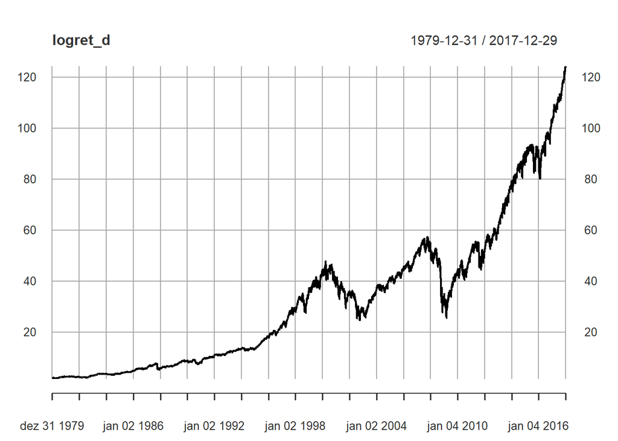

```r
plot(logret_d)
```

```r
logret_w = apply.weekly(wilsh,sum)
```

Visualizando as tres primeiras linhas

```r
round(head(logret_w,3),6)
```

```
##              TR
## 1980-01-04 5.64
## 1980-01-11 9.65
## 1980-01-18 9.84
```

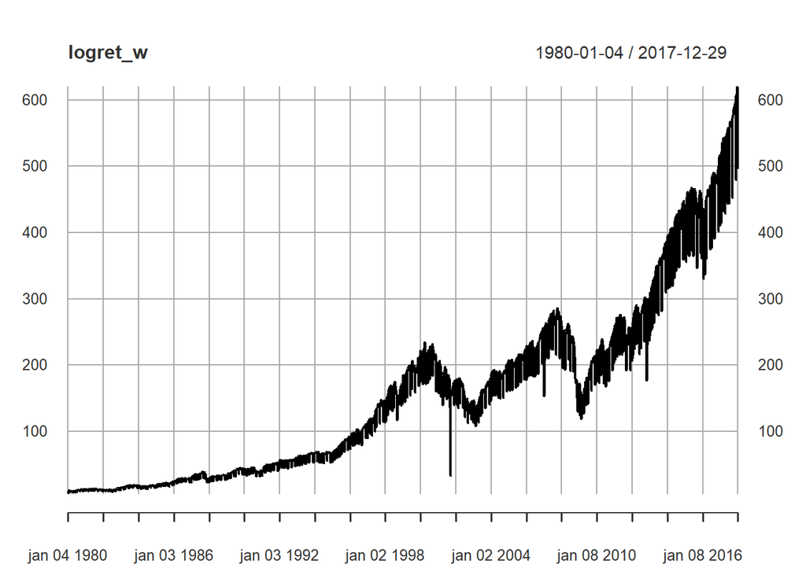

```r
plot(logret_w)
```

```r
logret_m = apply.monthly(wilsh,sum)
```

Visualizando as tres primeiras linhas

```r
round(head(logret_m,3),6)
```

```
##               TR
## 1979-12-31  1.90
## 1980-01-31 41.38
## 1980-02-29 41.19
```

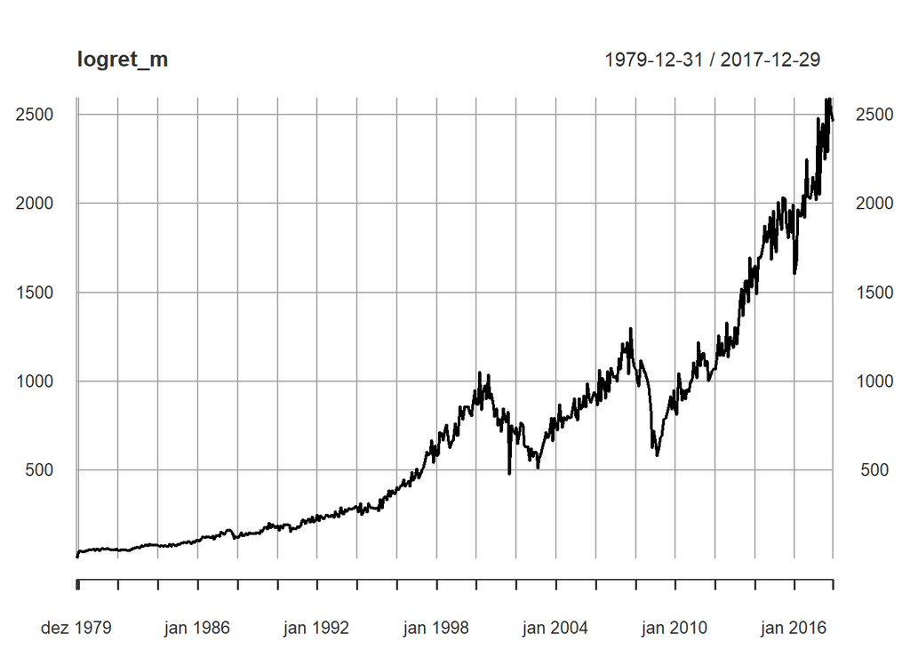

```r
plot(logret_m)
```

```r
logret_q = apply.quarterly(wilsh,sum)
```

Visualizando as tres primeiras linhas

```r
round(head(logret_q,3),6)
```

```
##                TR
## 1979-12-31   1.90
## 1980-03-31 121.59
## 1980-06-30 121.63
```

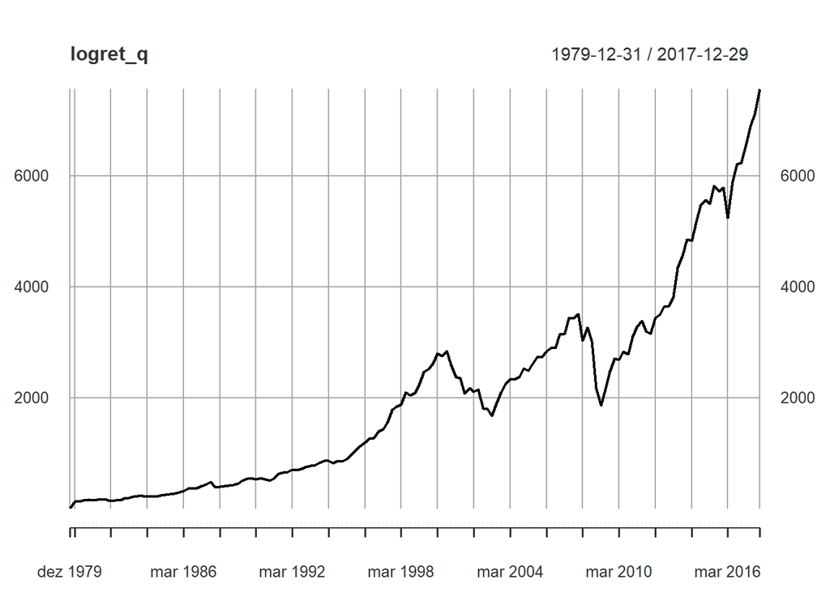

```r
plot(logret_q)
```

```r
logret_y = apply.yearly(wilsh,sum)
```

Visualizando as tres primeiras linhas

```r
round(head(logret_y,3),6)
```

```
##                TR
## 1979-12-31   1.90
## 1980-12-31 544.05
## 1981-12-31 628.12
```

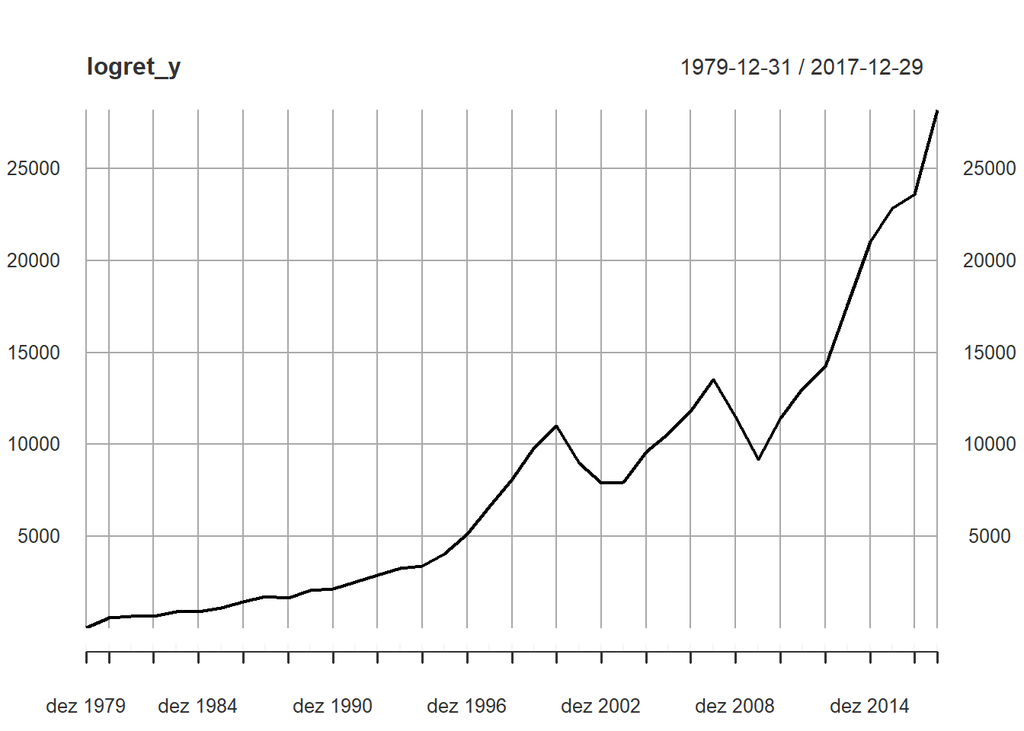

```r
plot(logret_y)
```